# STA 490 Assignments #2 and #3

HTML Presentation - Linear Regression Modeling

HTML Slides Due: Sunday, 9/25 Oral Presentation: 9/27 and 9/29

# 1 Objectives

The objectives of this assignment are

- perform linear regression analysis you learned in STA319;
- prepare HTML-based slides using relevant R packages via R Markdown.
- give an oral presentation in class to report the regression results.

# 2 Materials

The main task for week #5 is to review regression modeling. This assignment serves as a rigorous review of the regression techniques you learned in STA 319. Please go to the following web page to find a data set at your preference to build a linear regression model:

https://people.sc.fsu.edu/~jburkardt/datasets/regression/regression.html

There are 60+ data sets on the web above the web page. They are all good for regression analysis. After selecting your data set, please go to the D2L discussion forum to write a sentence description so your classmates will not use the same data set for their assignments. To post in D2L discussion Forum: `log into D2L -> STA 490 Course Page -> Communication -> Discussion`.

**Read Data to R Directly from Web Page**

Since all data sets are in the .txt format, you can use the R function `read.table` to read the data set to R directly. Next, I use the data set `x61_01.txt` as an example to show you how to read this data set into R. The data set is at (https://people.sc.fsu.edu/~jburkardt/datasets/regression/x61_01.txt). The URL will be placed in `read.table`. A screenshot is given below.

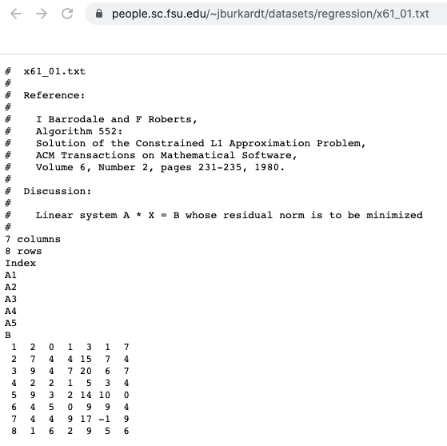

```r
include_graphics("https://raw.githubusercontent.com/pengdsci/STA490/main/images/dataset_x61_01.png")
```

```r
# we use skip = 23 to skip the first 23 rows since they are not data lines!
x61.01 = read.table("https://people.sc.fsu.edu/~jburkardt/datasets/regression/x61_01.txt", skip = 23)
# next we rename the automatically generated variables using the original names given in the description
# using function names().
names(x61.01) = c("Index", "A1", "A2", "A3", "A4", "A5", "B")
# check the data set was read correctly for the next step analysis
kable(x61.01)  # load package {knitr}
```

| Index | A1 | A2 | A3 | A4 | A5 | B |
| --- | --- | --- | --- | --- | --- | --- |
| 1 | 2 | 0 | 1 | 3 | 1 | 7 |
| 2 | 7 | 4 | 4 | 15 | 7 | 4 |
| 3 | 9 | 4 | 7 | 20 | 6 | 7 |
| 4 | 2 | 2 | 1 | 5 | 3 | 4 |
| 5 | 9 | 3 | 2 | 14 | 10 | 0 |
| 6 | 4 | 5 | 0 | 9 | 9 | 4 |
| 7 | 4 | 4 | 9 | 17 | -1 | 9 |
| 8 | 1 | 6 | 2 | 9 | 5 | 6 |

# 3 HTML Slides Preparation

Prepare an HTML presentation with up to 10 slides. The required components are

1. The research / practical question(s)
2. Description of data
3. Build a model and perform diagnostics
4. Report the final model (inference of the regression coefficients) and interpret the output.
5. Conclusions.

You are expected to include both tables and graphs in the HTML presentation.

# 4 Publishing Your HTML Presentation

You are expected to publish your HTML presentation on either RPubs or GitHub.

- To use RPubs (https://rpubs.com/), you need to create an account. Once you log into your account, you can publish you HTML document by `Publish` in the top-right corner of the preview or click the `Publish` button in the R Markdown source window (also in the top-right corner of the window).
- To host the HTML presentation on GitHub, you are encouraged to create and separate folder to store all related files (including images, data sets, etc.).
- Add the link to your final presentation to your personal web page you created in assignment #1.

# 5 Timelines

# 6 Oral Presentation Schedule

The order of the presentation is based on the alphabetical order of your last names.

**Tuesday, 9/27**: Coleman, Heneghan, Liu, and Parker.

**Thursday, 9/29**: Randazzo, Shin, Taylor, and Zhang.

Please keep in mind that your 10 minutes include QA time. The actual presentation time is about 7-8 minutes.

# 7 Assessments

Both HTML slides (assignment #2) and oral presentation (assignment #3) will be evaluated. The HTML slides will be evaluated based on whether all required components are included, whether the key analysis results are appropriately summarized in the HTML slides, and whether the presentation is correctly published on either RPubs or GitHub or both.

The oral presentation will be counted as assignment #3 and will be graded based on the rubrics that can be found at (https://pengdsci.github.io/STA490/w05-ProjectPresentationRubrics.html).

# 8 Submissions

After you finish the HTML slides, you must publish them on either GitHub or RPubs. You should review your slides on GitHub or RPubs and make sure your presentation is bug-free. The last step is to copy the URL and paste it to the D2L drop box. No other files are expected to be uploaded to the D2L drop box.